# Species metadata description

# Biodiversity mapping

The following pdf gives a description of the data used in the pipeline run that corresponds to the folder this document resides in. It should be used as a guide for anyone who wants to know more about the data used in the corresponding outputs (maps and datasets) and/or would like to replicate the data.

We begin with basic information about the pipeline run.

| Characteristic | Value |
| --- | --- |
| Date | 2023-10-26 |
| Taxa | spiders, scorpionflies, beetles, poaSpecies |
| Region type | county |
| Region code | 50 |
| Total species | 1775 |
| Total datasets used | 13 |
| DOI | 10.15468/dl.xgu7dd |

In addition to the above, data was downloaded with a maximum uncertainty regarding coordinates of 100 metres.

| taxa | Total species |
| --- | --- |
| beetles | 1357 |
| poaSpecies | 175 |
| scorpionflies | 5 |
| spiders | 238 |

| dsName | Observations |
| --- | --- |
| Vascular plant field notes, NTNU University Museum | 138480 |
| ANOData | 18688 |
| Norwegian Species Observation Service | 12888 |
| NINA insect database | 11613 |
| Terrestrial and limnic invertebrates systematic collection, NTNU University Museum | 3929 |
| Jordal | 2896 |
| National insect monitoring in Norway | 2383 |
| Vascular plant herbarium TRH, NTNU University Museum | 1141 |
| Overvåking av semi-naturlig eng (ASO) | 494 |
| iNaturalist Research-grade Observations | 405 |

The following gives species richness for observations across the surveyed region by taxa.

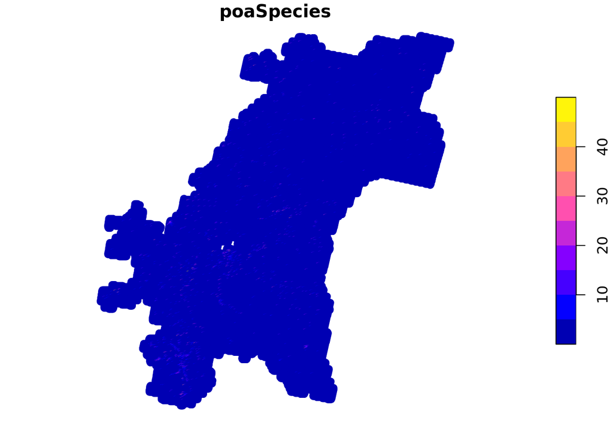

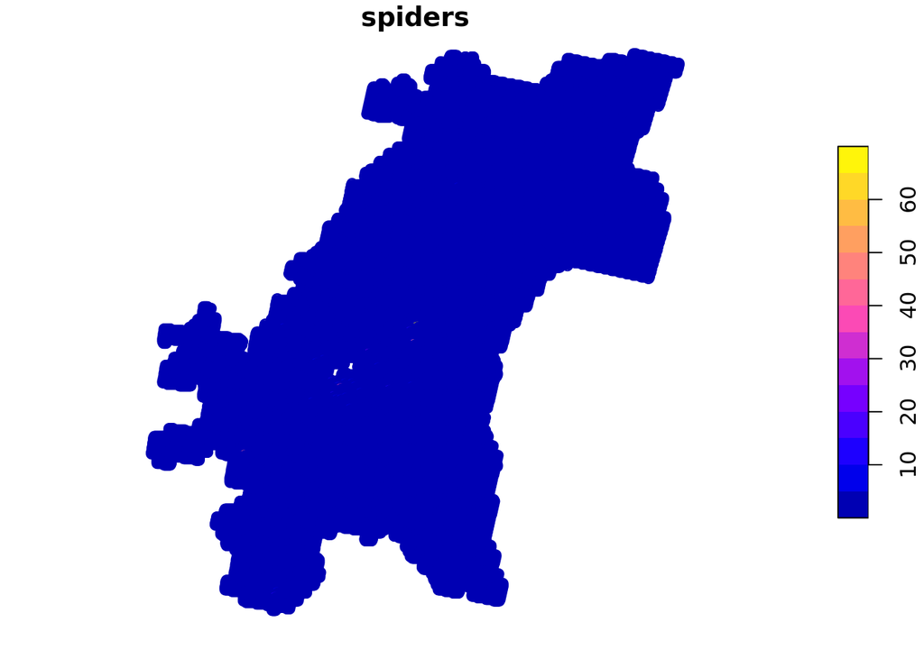

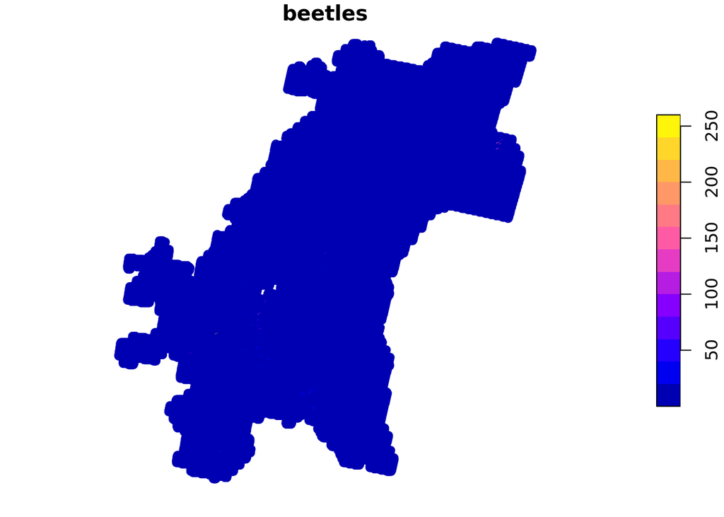

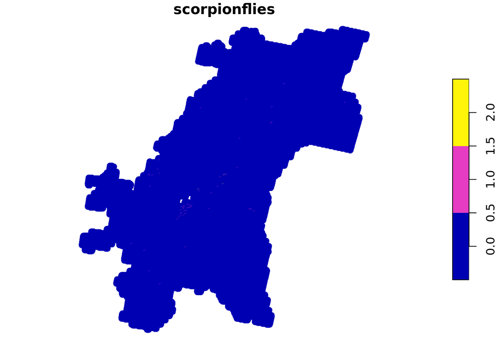

## Appendices

### Appendix 1

The tables below give further information on the observations used for our pipeline run.

Total numbers of observations used in pipeline run for each dataset by taxa.

| taxa | dsName | Observations |
| --- | --- | --- |
| beetles | NINA insect database | 8421 |
| beetles | Norwegian Species Observation Service | 5322 |
| beetles | Terrestrial and limnic invertebrates systematic collection, NTNU University Museum | 3658 |
| beetles | National insect monitoring in Norway | 1331 |
| beetles | iNaturalist Research-grade Observations | 147 |
| beetles | Entomology, Oslo (O) UiO | 58 |
| beetles | Artportalen (Swedish Species Observation System) | 9 |
| poaSpecies | Vascular plant field notes, NTNU University Museum | 138480 |
| poaSpecies | ANOData | 18688 |
| poaSpecies | Norwegian Species Observation Service | 5877 |
| poaSpecies | Jordal | 2896 |
| poaSpecies | Vascular plant herbarium TRH, NTNU University Museum | 1141 |
| poaSpecies | Overvåking av semi-naturlig eng (ASO) | 494 |
| poaSpecies | Vascular Plant Herbarium, Oslo (O) UiO | 301 |
| poaSpecies | iNaturalist Research-grade Observations | 213 |
| poaSpecies | Artportalen (Swedish Species Observation System) | 13 |
| scorpionflies | Norwegian Species Observation Service | 122 |
| scorpionflies | Terrestrial and limnic invertebrates systematic collection, NTNU University Museum | 16 |
| scorpionflies | iNaturalist Research-grade Observations | 1 |
| spiders | NINA insect database | 3192 |
| spiders | Norwegian Species Observation Service | 1567 |
| spiders | National insect monitoring in Norway | 1052 |
| spiders | Terrestrial and limnic invertebrates systematic collection, NTNU University Museum | 255 |
| spiders | iNaturalist Research-grade Observations | 44 |
| spiders | Artportalen (Swedish Species Observation System) | 1 |